# Calaveras River

Sadie Gill, Mark Tompkins

July 2020

## Future Data Improvements

None planned.

## Instream Spawning and Rearing Habitat

**Data Source:** [FISHBIO Environmental and Thomas R. Payne & Associates 2009](https://s3-us-west-2.amazonaws.com/cvpiahabitat-r-package/cvpia-sit-model-inputs/FishBio_Payne2009_CalaverasInstreamFlowStudy.pdf) (pgs. 18-19)

There is no habitat modeling available for Fall Run Chinook Salmon on the Calaveras River. Instream spawning and rearing habitat for Steelhead in the Calaveras River is used as a proxy for Chinook. The data are based on an instream flow study conducted by FISHBIO and Thomas Payne for the Stockton East Water District. They used a Physical Habitat Simulation model on four reaches to find a relationship between stream flow and suitable Steelhead habitat. Graphs showing the original data are on pages 18-19 of the study report linked above. The Steelhead spawning habitat data from Mark Gard were cross-referenced with the original FISHBIO data and amended to include the original FISHBIO data. The data were digitized from the flow : area curves using this [website](https://automeris.io/WebPlotDigitizer/). Values from the four reaches were first compiled into a spreadsheet. For each reach, the data were then weighted by reach length to find the weighted average of the Steelhead spawning and rearing weighted usable area (WUA) in Calaveras River. This approach was developed in coordination with Mark Gard from the California Department of Fish and Wildlife. Cells A16:D26 were used with a reach length of 18,282 ft, A30:D40 with a reach length of 25,438 ft, and A43:D43 with a reach length of 27,867 ft.

### Spawning and Rearing Data

The instream spawning and rearing habitat data described above for Steelhead (ST) are combined for use in the Decision Support Model (DSM) in the following format. Units are in square feet per 1000 feet.

Header Descriptions: flow_cfs = flow in cubic feet per second, ST_spawn_wua = Steelhead spawning WUA, ST_fry_wua = Steelhead Fry WUA, ST_juv_wua = Steelhead Juvenile WUA, watershed = section of stream modeled for CVPIA SDM

| flow_cfs | ST_spawn_wua | ST_fry_wua | ST_juv_wua | watershed |
| --- | --- | --- | --- | --- |
| 12 | 1738.836 | 4795.512 | 4179.246 | Calaveras River |
| 35 | 5142.170 | 4086.778 | 5806.281 | Calaveras River |
| 50 | 6617.992 | 3532.560 | 6418.567 | Calaveras River |
| 100 | 8294.504 | 3047.828 | 7332.643 | Calaveras River |
| 150 | 7935.804 | 2729.225 | 7278.300 | Calaveras River |

*… with 5 more rows*

### Spawning WUA

The following plot shows the weighted usable spawning area (WUA) in square feet per thousand feet for Steelhead. These area per length rates are multiplied by the total spawning reach length mapped by the Science Integration Team (SIT) to estimate available habitat.

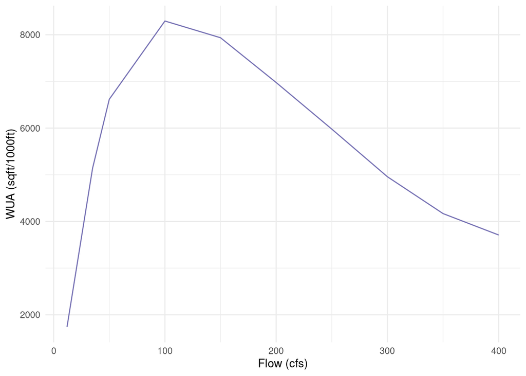

### Rearing WUA

The following plot shows the rearing WUA in square feet per thousand feet for Steelhead fry and juvenile. These rates are multiplied by the total rearing reach length mapped by the SIT to estimate available habitat.

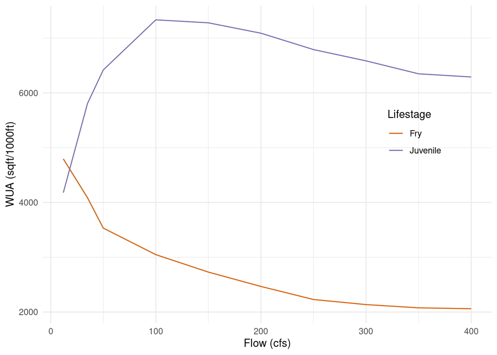

## Floodplain Rearing Habitat

**Data Source:** Scaled from a Tuolumne River flow to floodplain area relationship generated with a [TUFLOW hydraulic model with 1D channel and 2D overbank components](https://s3-us-west-2.amazonaws.com/cvpiahabitat-r-package/cvpia-sit-model-inputs/Tuolumne_W-AR_21__Study+Report.pdf). See [Tuolumne River modeling documentation](http://cvpia-habitat-docs-markdown.s3-website-us-west-2.amazonaws.com/watershed/tuolumne_river.html) for more details.

There was no watershed specific hydraulic modeling available for Calaveras River. A flow to inundated floodplain area relationship was generated for Calaveras River by scaling the flow to inundated floodplain area relationship for Tuolumne River. This scaling used the ratio of mean flow from December to June between the modeled and unmodeled watershed. Flows and corresponding inundated floodplain areas per unit length were calculated for Calaveras River as 20% of Tuolumne River. Of the entire mapped 18.5 miles rearing extent in Calaveras River, 18.5 miles were classified as low gradient and 0 miles were classified as high gradient based on a geomorphic analysis of long profile slopes and valley widths. The area per unit length was scaled by a factor of 0.1 for the high gradient extent. There was no scaling factor applied to the low gradient extent.

## Floodplain Data

The areas represent total inundated area in acres.

Header Descriptions: flow_cfs = flow in cubic feet per second, FR_floodplain_acres = Fall Run Chinook floodplain acres, ST_floodplain_acres = Steelhead floodplain acres, watershed = section of stream modeled for CVPIA SDM

| flow_cfs | FR_floodplain_acres | ST_floodplain_acres | watershed |
| --- | --- | --- | --- |
| 200 | 0.00 | 0.00 | Calaveras River |
| 251 | 2.45 | 2.45 | Calaveras River |
| 301 | 5.23 | 5.23 | Calaveras River |
| 351 | 7.97 | 7.97 | Calaveras River |
| 401 | 10.70 | 10.70 | Calaveras River |

*… with 28 more rows*

## Floodplain Plot

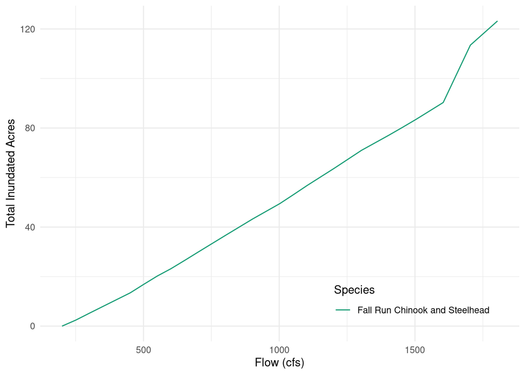